# Churn Analysis: Explorative Datenanalyse

Andreas Warntjen

23.02.2016 (überarbeitet 14.11.2022)

# Zusammenfassung

Kunden zu halten ist häufig günstiger als neue Kunden zugewinnen. Deshalb ist für viele Firmen die Analysen von Kündigungsverhalten wichtig. In diesem Beispielsdatensatz aus der Telekommunikationsbranche gibt es 21 Variablen zum Kündigungsverhalten sowie zum sozio-ökonomischen Status und den Vertragsmodalitäten von 7043 Kunden. 27% der Kunden in dem Datensatz haben ihren Vertrag gekündigt.

Die explorative Datenanalyse zeigt teilweise bereits deutliche Unterschiede im Kündigungsverhalten zwischen Kunden mit verschiedenen sozio-ökonomischen Status oder unterschiedlichen Vertragsmodalitäten. Insbesondere kündigen Neu-Kunden und Kunden mit monatlicher Vertragsdauer relativ häufig. Kunden mit Partnern oder Kindern kündigen seltener, Rentner hingegen kündigen vergleichsweise häufig.

# Deskriptive Statistik

Der Datensatz besteht aus 7043 Beobachtungen für 21 Variablen.

Die Daten wurden am 1.2.2016 von [community.watsonanalytics.com](https://community.watsonanalytics.com/telco-customer-churn/) heruntergeladen. Leider gibt es keine vollständige Dokumentation mit Beschreibungen der einzelnen Variablen. Ich gehe also etwa davon aus, dass die bisherige Vertragsdauer (tenure) in Monaten und die Gesamtgebühren (TotalCharges) in US Dollar angegeben sind.

Für die weitere Auswertung übersetzen wir zunächst die Ausprägungen ins Deutsche.

```r
### Datenaufbereitung
# Classes sind schon richtig definiert, bis auf SeniorCitizen
my.data$SeniorCitizen<- factor(SeniorCitizen, labels = c("Nein", "Ja"))

# Übersetzung der Wertelabels
levels(my.data$Churn)[levels(Churn)=="No"] <- "Nein"
levels(my.data$Churn)[levels(Churn)=="Yes"] <- "Ja"
levels(my.data$Contract)[levels(Contract)=="Month-to-month"] <- "Monatlich"
levels(my.data$Contract)[levels(Contract)=="One year"] <- "1 Jahr"
levels(my.data$Contract)[levels(Contract)=="Two year"] <- "2 Jahre"
levels(my.data$gender)[levels(gender)=="Female"] <- "Frau"
levels(my.data$gender)[levels(gender)=="Male"] <- "Mann"
levels(my.data$Partner)[levels(Partner)=="No"] <- "Nein"
levels(my.data$Partner)[levels(Partner)=="Yes"] <- "Ja"
levels(my.data$Dependents)[levels(Dependents)=="No"] <- "Nein"
levels(my.data$Dependents)[levels(Dependents)=="Yes"] <- "Ja"
```

Im nächsten Schritt verschaffen wir uns einen Überblick über den Datensatz. Dabei geht es darum sich zum einen mit den Daten vertraut zu machen und zum anderen Ungereimtheiten in den Daten - etwa auf Grund von Eingabefehlern - zu finden.

```r
## Fehlende Daten oder mögliche Eingabefehler
## Plausibilitätscheck
summary(my.data)
```

```
##       customerID    gender     SeniorCitizen Partner     Dependents
##  0002-ORFBO:   1   Frau:3488   Nein:5901     Nein:3641   Nein:4933
##  0003-MKNFE:   1   Mann:3555   Ja  :1142     Ja  :3402   Ja  :2110
##  0004-TLHLJ:   1
##  0011-IGKFF:   1
##  0013-EXCHZ:   1
##  0013-MHZWF:   1
##  (Other)   :7037
##      tenure      PhoneService          MultipleLines     InternetService
##  Min.   : 0.00   No : 682     No              :3390   DSL        :2421
##  1st Qu.: 9.00   Yes:6361     No phone service: 682   Fiber optic:3096
##  Median :29.00                Yes             :2971   No         :1526
##  Mean   :32.37
##  3rd Qu.:55.00
##  Max.   :72.00
##
##              OnlineSecurity              OnlineBackup
##  No                 :3498   No                 :3088
##  No internet service:1526   No internet service:1526
##  Yes                :2019   Yes                :2429
##
##
##
##
##             DeviceProtection              TechSupport
##  No                 :3095    No                 :3473
##  No internet service:1526    No internet service:1526
##  Yes                :2422    Yes                :2044
##
##
##
##
##               StreamingTV              StreamingMovies      Contract
##  No                 :2810   No                 :2785   Monatlich:3875
##  No internet service:1526   No internet service:1526   1 Jahr   :1473
##  Yes                :2707   Yes                :2732   2 Jahre  :1695
##
##
##
##
##  PaperlessBilling                   PaymentMethod  MonthlyCharges
##  No :2872         Bank transfer (automatic):1544   Min.   : 18.25
##  Yes:4171         Credit card (automatic)  :1522   1st Qu.: 35.50
##                   Electronic check         :2365   Median : 70.35
##                   Mailed check             :1612   Mean   : 64.76
##                                                    3rd Qu.: 89.85
##                                                    Max.   :118.75
##
##   TotalCharges     Churn
##  Min.   :  18.8   Nein:5174
##  1st Qu.: 401.4   Ja  :1869
##  Median :1397.5
##  Mean   :2283.3
##  3rd Qu.:3794.7
##  Max.   :8684.8
##  NA's   :11
```

Es gibt nur wenige fehlende Werte bei TotalCharges und keine Auffälligkeiten (wie etwa negative Werte für Charges).

Mit den Befehlen

- [table()](https://www.statmethods.net/stats/frequencies.html)
- [prop.table()](https://www.statmethods.net/stats/frequencies.html)
- [summary()](https://www.statology.org/summary-function-in-r/)
- [hist()](https://www.datamentor.io/r-programming/histogram/)

verschaffen wir uns einen weitergehenden Einblick in die Daten und können darüber schon einige interessante Einsichten in die Kunden gewinnen (Ergebnisse nicht angezeigt / auskommentiert. table() und prop.table() erstellen Tabellen mit Häufigkeitsverteilungen, summary() fasst eine numerische Variablen (oder alle Variablen eines Datensatzes wie hier) zusammen und hist() erstellt ein einfaches Histogram, um die Verteilung einer numerischen Variablen zu visualisieren. Sie sind alle R-nativ und benötigen keine zusätzlichen Bibliotheken. Für die Kommunikation ist die Darstellungsform zu krude, aber für die eigene Datenexploration sind diese Grundfunktionen sehr nützlich. Weiter unten erstellen wir ansprechendere Datenvisualisierungen mit ggplot.

```r
### Deskriptive Statistik

# ### Explorative Datenanalyse
# ## Univariate Darstellungen
# barplot(table(Churn), main="Churn")
# # Churn nicht balanced
#
# layout(matrix(1:8, nc=2))
# barplot(table(gender), main="Gender")
# barplot(table(SeniorCitizen), main="Senior Citizen")
# barplot(table(Dependents), main="Dependents")
# barplot(table(PhoneService), main="Phone Service")
# barplot(table(MultipleLines), main="Multiple Lines")
# barplot(table(OnlineSecurity), main="Online Security")
# barplot(table(OnlineBackup), main="Online Backup")
# barplot(table(DeviceProtection), main="DeviceProtection")
# # Wenige Senior Citizens, wenige ohne PhoneService,
#
# layout(matrix(1:6, nc=2))
# barplot(table(TechSupport), main="Tech Support")
# barplot(table(StreamingTV), main="Streaming TV")
# barplot(table(StreamingMovies), main="Streaming Movies")
# barplot(table(Contract), main="Contract")
# barplot(table(PaperlessBilling), main="Paperless Billing")
# barplot(table(PaymentMethod), main="Payment Method")
# # Tech Support, Streaming TV, Streaming Movies hängt von Internet ab
# # Monatlicher Vertrag am häufigsten
#
# hist(MonthlyCharges, main="Monthly Charges")
# # Multimodale Verteilung für monthly charges
# hist(TotalCharges, main="Total Charges")
# # Schiefe Verteilung, wenige sehr hohe Werte
# #
# # Häufigkeitsverteilung in Prozentangaben
# prop.table(table(Churn))
# prop.table(table(gender))
# prop.table(table(Partner))
# prop.table(table(Dependents))
# prop.table(table(SeniorCitizen))
# prop.table(table(PhoneService))
# prop.table(table(InternetService))
# prop.table(table(Contract))
# summary(tenure)
# hist(tenure)
# cumsum(prop.table(table(tenure)))
# prop.table(table(PaperlessBilling))
# prop.table(table(PaymentMethod))
# # Die Variablen für Zusatzdienste (z.B. OnlineSecurity) hängen vom Basisdienst ab (InternetService)
# table(InternetService)
# table(OnlineSecurity)

# Kleinerer Datensatz für Internetkunden
my.data.internet<-subset(my.data, InternetService!="No")
my.data.internet<-droplevels(my.data.internet)

# prop.table(table(my.data.internet$OnlineSecurity))
# prop.table(table(my.data.internet$OnlineBackup))
# prop.table(table(my.data.internet$DeviceProtection))
# prop.table(table(my.data.internet$TechSupport))
# prop.table(table(my.data.internet$StreamingTV))
# prop.table(table(my.data.internet$StreamingMovies))
#
# # Gebühren
# summary(MonthlyCharges)
# hist(MonthlyCharges)
# summary(TotalCharges)
# hist(TotalCharges)
```

Für die weitere Analyse ist die Datenvisualisierung essentiell. Im Folgenden nutzen wir die Bibliothek ggplot, mit der sich eine Vielzahl von maßgeschneiderten Grafiken erstellen lässt. [ggplot()](http://sthda.com/english/wiki/ggplot2-essentials) nutzt eine universelle Sprache von Grafiken (“grammar of graphics”), um mit einer einheitlichen Syntax alle erdenklichen Grafiken erstellen zu können. Insbesondere sind dies die darzustellende Information / Variablen (aesthetics) und die (geometrische) Darstellung (geoms). Der Aufbau des Befehls ggplot() ist die Definition des Datensatzens (“my.data”) und der Variablen. Für eine univariate Datenvisualisierung ist dies die X-Variable. In der folgenden Grafik ist dies etwa tenure. Die Definition der Variablen erfolgt in dem Abschnitt zu aesthetics (aes). Danach spezifizieren wir die Art der Darstellung mit geom_histogram und legen weitere Aspekte fest (Beschriftung der Achsen mit labs, die Markierung der Y-Achse mit scale_y_continuous).

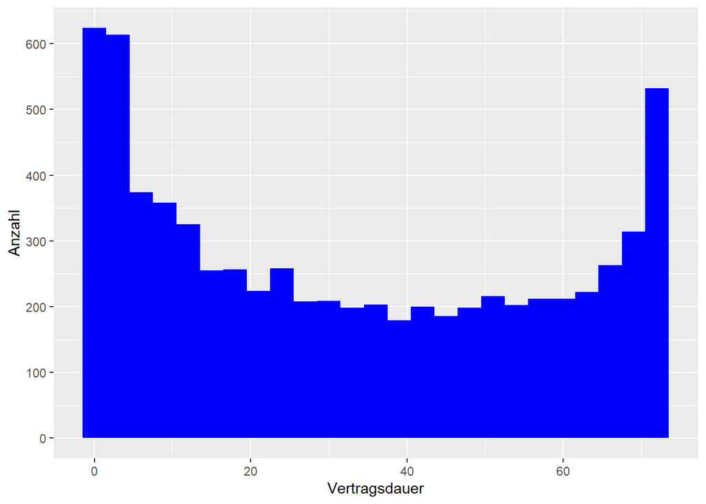

```r
# Grafik für Vertragsdauer und monatliche Gebühren

g1<-ggplot(my.data, aes(x=tenure), na.rm=T)+geom_histogram(binwidth=3, fill="blue")+labs(x="Vertragsdauer",
y="Anzahl")+scale_y_continuous(breaks=seq(0, 1000, 100))
g1
```

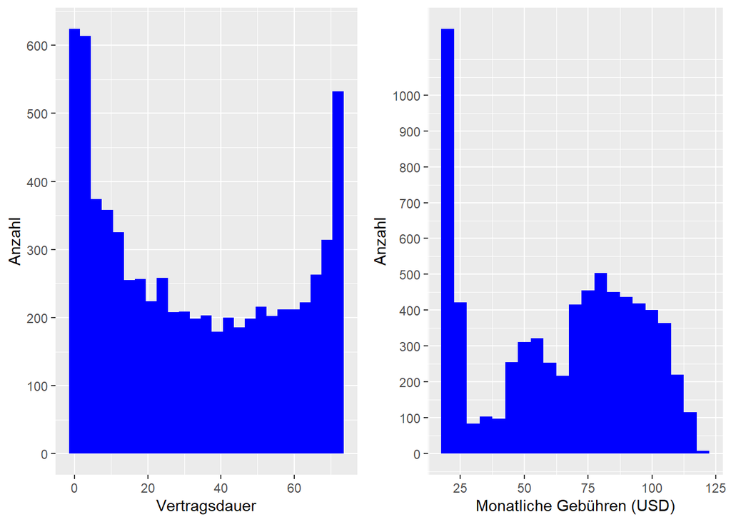

```r
g2<-ggplot(my.data, aes(x=MonthlyCharges))+geom_histogram(binwidth=5, fill="blue")+labs(x="Monatliche Gebühren (USD)",
y="Anzahl")+scale_y_continuous(breaks=seq(0, 1000, 100))
grid.arrange(g1, g2, ncol=2, nrow=1)
```

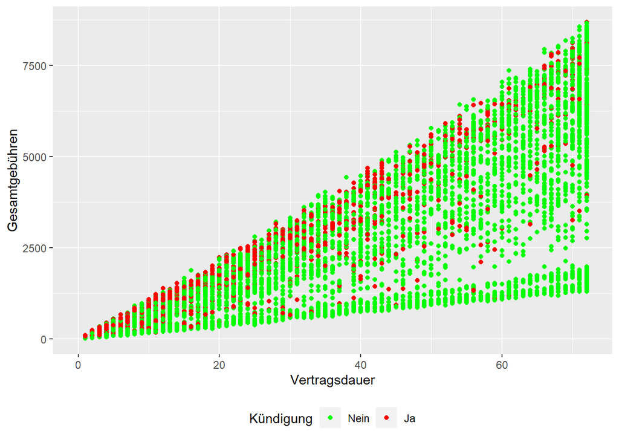

```r
ggplot(my.data, aes(x=tenure, y=TotalCharges, colour=Churn))+geom_point()+scale_color_manual(values=c("green", "red"),
name="Kündigung")+theme(legend.position="bottom")+labs(x="Vertragsdauer", y="Gesamtgebühren")
```

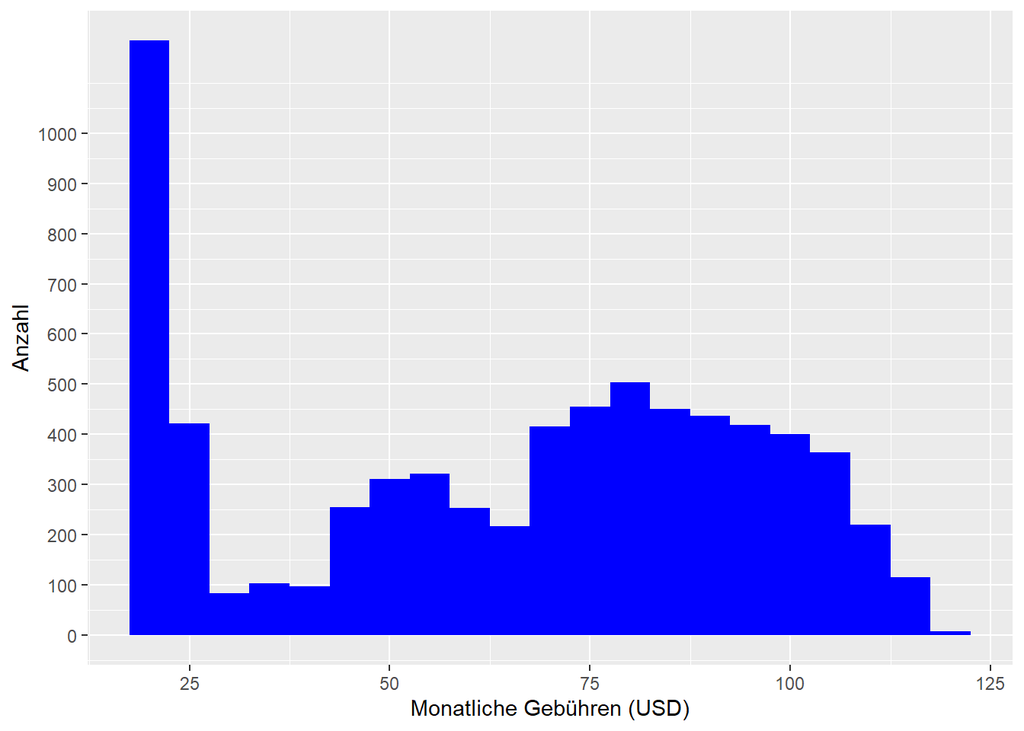

```r
g2
```

*Grafik 1*: Häufigkeitsverteilung für Vertragsdauer und monatliche Gebühren

Die monatlichen Ge-bühren und die Vertragsdauer ist bi-modal verteilt: es gibt viele Kunden mit einer sehr kurzen Vertragsdauer und niedrigen monatlich-en Gebühren (Grafik 1). Dem stehen relativ viele Kunden mit einer sehr hohen Vertragsdauer entgegen. Die Gebühren liegen ansonsten vor allem zwischen 70 und 90 USD.

# Explorative Datenanalyse: Sozio-ökonomische Faktoren, Kundenbeziehung und Kündigungsverhalten

In einem ersten Analyseschritt betrachten wir explorativ den bivariaten Zusammenhang zwischen Kündigungsverhalten und sozio-ökonomischen Faktoren sowie der Kundenbeziehung (Vertragsdauer, Vertragsumfang, Gebühren).

Grafik 2 vergleicht das Kündigungsverhalten zwischen verschiedenen sozio-ökonomischen Gruppen. Die Höhe des grünen Balkenanteils entsprich dem Prozentantail an Kunden in dieser Gruppe, die nicht gekündigt haben. Wir können sehen, dass Kunden mit Kindern und Partner seltener gekündigt haben als alleinstehende Kunden. Rentner kündigen häufiger als jüngere Kunden. Zwischen männlichen und weiblichen Kunden scheint es keinen Unterschied im Kündigungsverhalten zu geben.

Die Darstellung als Prozent erfolgt über percent_format(). Mit scale_fill_manual() geben wir die Farbe der Balken vor. Mit den Befehlen themes() und guides() spezifieren wir die allgemeine Darstellungsweise (hier: die Position der Legende) und Einzelheiten der Legende. Um eine gemeinsame Legende zu haben brauchen wir eine eigene Funktion.

```r
# Funktion für gemeinsame legend
#http://www.sthda.com/english/wiki/ggplot2-easy-way-to-mix-multiple-graphs-on-the-same-page-r-software-and-datavisualization#grid.arrange-create-and-arrange-multiple-plots
get_legend<-function(myggplot){
 tmp <- ggplot_gtable(ggplot_build(myggplot))
 leg <- which(sapply(tmp$grobs, function(x) x$name) == "guide-box")
 legend <- tmp$grobs[[leg]]
 return(legend)
}
```

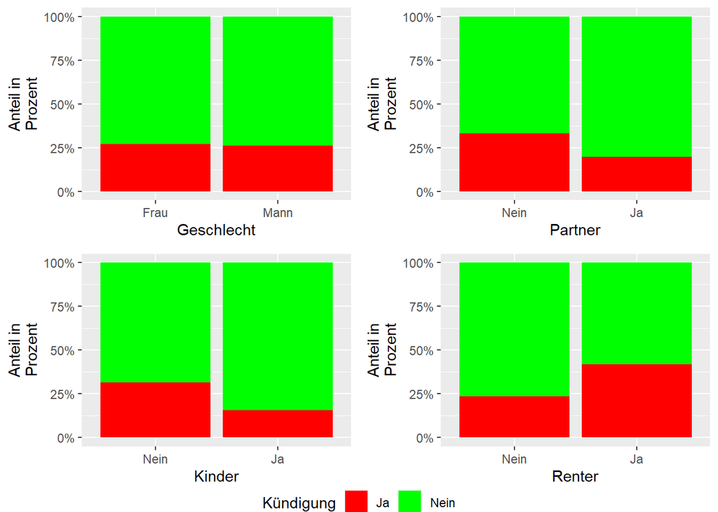

```r
# Interaktionseffekt Vertragsdauer und monatliche Gebühren?
## Bivariate Zusammenhänge mit der abhängigen Variable
# Sozioökonomische Variablen
f1<-ggplot(my.data, aes(x=gender, fill=Churn))+geom_bar(position="fill")+scale_y_continuous(labels =
percent_format())+scale_fill_manual(values=c("green", "red"), name="Kündigung")+guides(fill=guide_legend(reverse=T))+ylab("Anteil in
Prozent")+xlab("Geschlecht")+theme(legend.position="bottom")
f2<-ggplot(my.data, aes(x=Partner, fill=Churn))+geom_bar(position="fill")+scale_y_continuous(labels =
percent_format())+scale_fill_manual(values=c("green", "red"))+guides(fill=guide_legend(reverse=T))+ylab("Anteil in
Prozent")+xlab("Partner")+theme(legend.position="none")
f3<-ggplot(my.data, aes(x=Dependents, fill=Churn))+geom_bar(position="fill")+scale_y_continuous(labels =
percent_format())+scale_fill_manual(values=c("green", "red"))+guides(fill=guide_legend(reverse=T))+ylab("Anteil in
Prozent")+xlab("Kinder")+theme(legend.position="none")
f4<-ggplot(my.data, aes(x=SeniorCitizen, fill=Churn))+geom_bar(position="fill")+scale_y_continuous(labels =
percent_format())+scale_fill_manual(values=c("green", "red"))+guides(fill=guide_legend(reverse=T))+ylab("Anteil in
Prozent")+xlab("Renter")+theme(legend.position="none")

# Gemeinsame legend vorbereiten
legend <- get_legend(f1)
f1<-f1+theme(legend.position="none")

grid.arrange(f1, f2, f3, f4, legend, nrow=3, ncol=2, layout_matrix = rbind(c(1,2), c(3, 4), c(5,5)), widths = c(2.7, 2.7), heights = c(2.5, 2.5,
0.2))
```

*Grafik 2*: Kündigungen und sozio-ökonomische Gruppen

Das Kündigungsverhalten unterscheidet sich auch abhängig von der Länge der Vertragslaufzeit sowie der bisherigen Vertragsdauer und der Höhe der monatlichen Gebühren (Grafik 3). Verträge mit einer Vertragslaufzeit von einem Monat werden wesentlich häufiger gekündigt als Verträge mit einer ein- oder zweijährigen Laufzeit. Kunden, die schon länger einen Vertrag haben, kündigen proportional gesehen weniger als Neukunden. Ab einer Vertragsdauer von 20 Monaten bleiben mehr Kunden beim Unternehmen als kündigen. Kunden mit einer sehr geringen monatlichen Gebühr kündigen weniger häufig als Kunden mit höheren Gebühren.

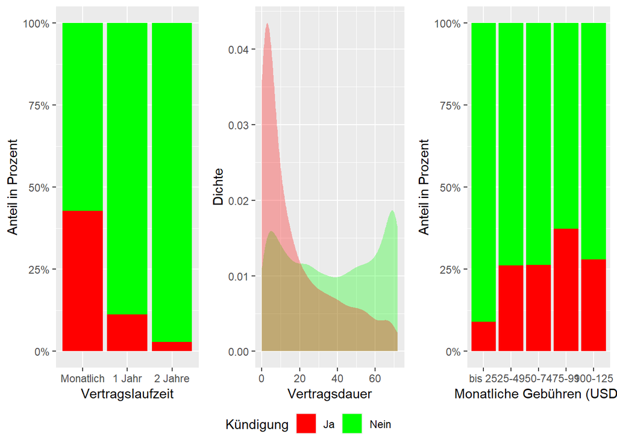

```r
# Dauer und Höhe der Gebühren
# prop.table(table(Churn, Contract))

h1<-ggplot(my.data, aes(x=Contract, fill=Churn))+geom_bar(position="fill")+scale_y_continuous(labels =percent_format())+scale_fill_manual(values=c("green", "red"), name="Kündigung")+guides(fill=guide_legend(reverse=T))+ylab("Anteil in Prozent")+xlab("Vertragslaufzeit")+theme(legend.position="bottom")

#ggplot(my.data, aes(x=Churn, y=tenure))+geom_boxplot()

h2<-ggplot(my.data, aes(x=tenure, fill=Churn))+geom_density(alpha=.3, color=NA)+scale_fill_manual(values=c("green", "red"), name="Kündigung")+labs(x="Vertragsdauer", y="Dichte")+theme(legend.position="none")

# ggplot(my.data, aes(x=Churn, y=MonthlyCharges))+geom_boxplot()+scale_fill_manual(values=c("green", "red"), name="Kündigung")

#ggplot(my.data, aes(x=MonthlyCharges, fill=Churn))+geom_density(alpha=.3, color=NA)+scale_fill_manual(values=c("green", "red"), name="Kündigung")

my.data$Monthly.cat<-cut(my.data$MonthlyCharges, seq(0,150,25))

h3<-ggplot(my.data, aes(x=Monthly.cat, fill=Churn))+geom_bar(position="fill")+scale_y_continuous(labels = percent_format())+scale_fill_manual(values=c("green", "red"))+guides(fill=guide_legend(reverse=T))+ylab("Anteil in Prozent")+xlab("Monatliche Gebühren (USD)")+theme(legend.position="none")+scale_x_discrete(labels=c("bis 25", "25-49", "50-74", "75-99","100-125"))

# ggplot(my.data, aes(x=Churn, y=TotalCharges))+geom_boxplot()
# ggplot(my.data, aes(x=TotalCharges, fill=Churn))+geom_density(alpha=.3, color=NA)
# Es gibt einen Zusammenhang zwischen Churn und tenure sowie MonthlyCharges

# Gemeinsame legend vorbereiten
legend <- get_legend(h1)
h1<-h1+theme(legend.position="none")

grid.arrange(h1, h2, h3, legend, nrow=2, ncol=3, layout_matrix = rbind(c(1,2, 3), c(4, 4,4)), widths = c(2.7, 2.7, 2.7), heights = c(2.5, 0.2))
```

*Grafik 3*: Kündigungen, Vertragsdauer und monatliche Gebühren

Im Vergleich der der Rechnungsart (digital /Papier) und der Zahlart von Kunden zeigen sich auch Unterschiede im Kündigungsverhalten (Grafik 4). Kunden mit digitalen Rechnungen sowie Kunden, die elektronisch per Scheck zahlen, kündigen häufiger. Zwischen den anderen Zahlarten bestehen hingegen keine nennenswerten Unterschiede im Kündigungsverhalten.

Wir kombinieren hier mehrere Grafiken über grid.arrange().

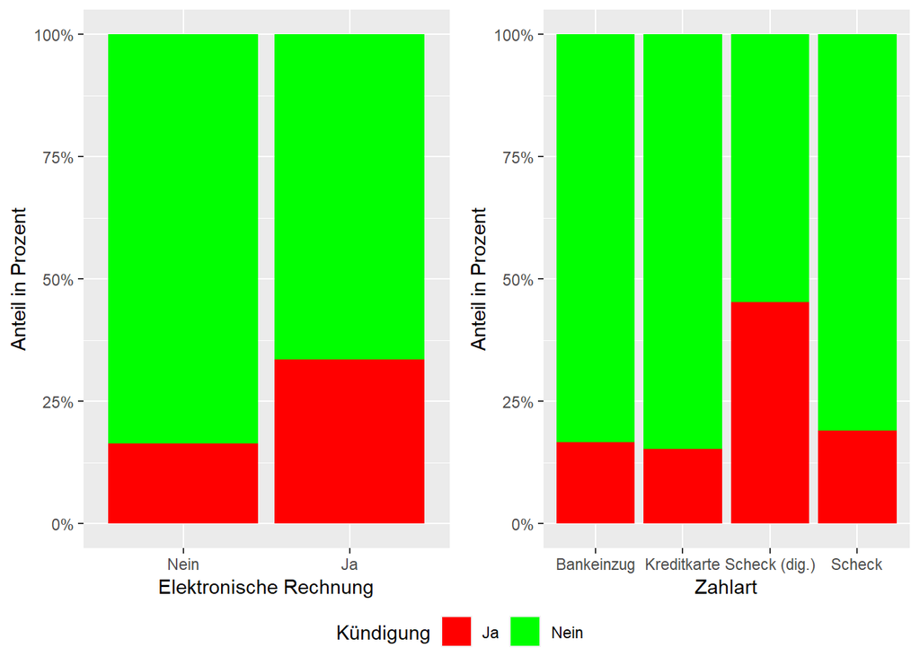

```r
i1<-ggplot(my.data, aes(x=PaperlessBilling, fill=Churn))+geom_bar(position="fill")+ylab("Anteil in Prozent")+scale_y_continuous(labels = percent_format())+scale_fill_manual(values=c("green", "red"), name="Kündigung")+xlab("Elektronische Rechnung")+scale_x_discrete(labels=c("Nein", "Ja"))+theme(legend.position="bottom")

i2<-ggplot(my.data, aes(x=PaymentMethod, fill=Churn))+geom_bar(position="fill")+scale_fill_manual(values=c("green", "red"), name="Kündigung")+ylab("Anteil in Prozent")+scale_y_continuous(labels = percent_format())+xlab("Zahlart")+scale_x_discrete(labels=c("Bankeinzug", "Kreditkarte", "Scheck (dig.)", "Scheck"))+theme(legend.position="none")

i1<-i1+theme(legend.position="none")

grid.arrange(i1, i2, legend, ncol=2, nrow=2, layout_matrix = rbind(c(1,2),c(3,3)), widths = c(2.7, 2.7), heights = c(2.5, 0.2))
```

*Grafik 4*: Kündigungen, Rechnungs- und Zahlart

Viele Kunden haben Zusatzdienstleistungen für ihre Internetverbindung abonniert. Grafik 5 vergleicht das Kündigungsverhalten zwischen Kunden mit und ohne die diversen Zusatzleistungen. Generell zeigt sich, dass Kunden mit Zusatzoptionen weniger häufig kündigen. Nur für die Streaming-Angebote gibt es keinen nennenswerten Unterschied im Kündigungsverhalten.

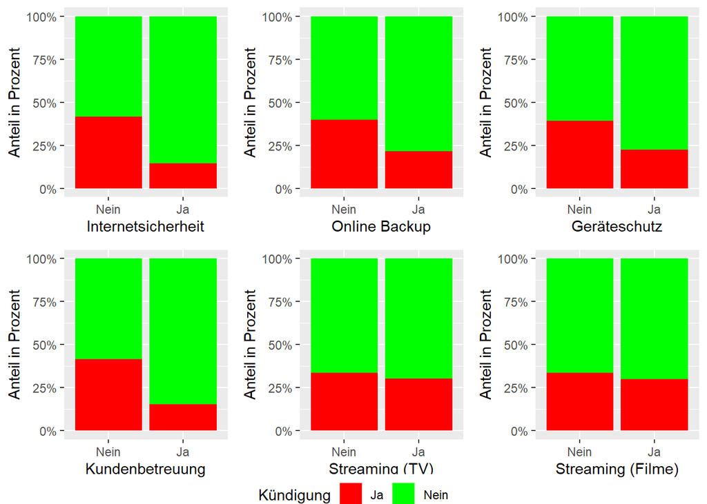

```r
j1<-ggplot(my.data.internet, aes(x=OnlineSecurity, fill=Churn))+geom_bar(position="fill")+scale_y_continuous(labels =percent_format())+scale_fill_manual(values=c("green", "red"))+ylab("Anteil in Prozent")+xlab("Internetsicherheit")+scale_x_discrete(labels=c("Nein", "Ja"))+theme(legend.position="bottom")

j2<-ggplot(my.data.internet, aes(x=OnlineBackup, fill=Churn))+geom_bar(position="fill")+scale_y_continuous(labels = percent_format())+scale_fill_manual(values=c("green", "red"))+ylab("Anteil in Prozent")+xlab("Online Backup")+scale_x_discrete(labels=c("Nein", "Ja"))+theme(legend.position="none")

j3<-ggplot(my.data.internet, aes(x=DeviceProtection, fill=Churn))+geom_bar(position="fill")+scale_y_continuous(labels = percent_format())+scale_fill_manual(values=c("green", "red"))+ylab("Anteil in Prozent")+xlab("Geräteschutz")+scale_x_discrete(labels=c("Nein", "Ja"))+theme(legend.position="none")

j4<-ggplot(my.data.internet, aes(x=TechSupport, fill=Churn))+geom_bar(position="fill")+scale_y_continuous(labels = percent_format())+scale_fill_manual(values=c("green", "red"))+ylab("Anteil in Prozent")+xlab("Kundenbetreuung")+scale_x_discrete(labels=c("Nein", "Ja"))+theme(legend.position="none")

j5<-ggplot(my.data.internet, aes(x=StreamingTV, fill=Churn))+geom_bar(position="fill")+scale_y_continuous(labels = percent_format())+scale_fill_manual(values=c("green", "red"))+ylab("Anteil in Prozent")+xlab("Streaming (TV)")+scale_x_discrete(labels=c("Nein","Ja"))+theme(legend.position="none")

j6<-ggplot(my.data.internet, aes(x=StreamingMovies, fill=Churn))+geom_bar(position="fill")+scale_y_continuous(labels = percent_format())+scale_fill_manual(values=c("green", "red"))+ylab("Anteil in Prozent")+xlab("Streaming (Filme)")+scale_x_discrete(labels=c("Nein", "Ja"))+theme(legend.position="none")

j1<-j1+theme(legend.position="none")

grid.arrange(j1, j2, j3, j4, j5, j6, legend, ncol=3, nrow=3, layout_matrix = rbind(c(1,2,3),c(4,5,6), c(7,7,7)), widths = c(2.7, 2.7, 2.7), heights= c(2.5, 2.5, 0.2))
```

```r
# Churn unterscheidet sich deutlich für Contract, SeniorCitizen, Partner,
# Dependents, Internetservice, OnlineSecurity, OnlineBackup, DeviceProtection,
# TechSupport, PaperlessBilling, PaymentMethod
```

*Grafik 5*: Kündigungen und Zusatzdienstleistungen für das Internet

# Fazit

Die explorative Datenanalyse zeigt teilweise deutliche Unterschiede im Kündigungsverhalten zwischen Kunden mit verschiedenen sozio-ökonomischen Status oder unterschiedlichen Vertrags-modalitäten. Insbesondere kündigen Neu-Kunden und Kunden mit monatlicher Vertragsdauer relativ häufig. Kunden mit Partnern oder Kindern kündigen seltener, Rentner hingegen kündigen vergleichsweise häufig. Kunden, die entweder sehr geringe monatliche Gebühren zahlen oder Zusatzleistungen gebucht haben, kündigen seltener.